# Extracting raster using vector

Tim Keitt

May 26, 2016

## Preliminaries

```r
# Make sure we're in the right place
if (!file.exists("rasvec.Rmd")) stop("This demo must be run from the same directory as the file")
```

## Species data

The R [dismo](https://cran.r-project.org/web/packages/dismo/index.html) package contains facilities for downloading biodiversity data and constructing species distribution models. This will illustrate pulling data from raster layers using vector (points in this case) locations.

Let’s try pulling occurrence records for the Golden-Cheeked Warbler, a threatened bird that breeds near Austin.

```r
pacman::p_load("dismo")
pacman::p_load("tigris")
pacman::p_load("sp")
pacman::p_load("rgeos")

# Since this is slow, I saved the result and reload here
# gcwa = gbif("Setophaga", "chrysoparia", removeZeros = TRUE)
gcwa = readRDS("gcwa.rds")

# Grab the boundary of Texas from the US Census
states = tigris::states(TRUE)
texas = subset(states, NAME == 'Texas')

epsg_3083 = "+proj=aea +lat_1=27.5 +lat_2=35 +lat_0=18 +lon_0=-100 +x_0=1500000 +y_0=6000000 +ellps=GRS80 +datum=NAD83 +units=m +no_defs"
epsg_4326 = "+proj=longlat +ellps=WGS84 +datum=WGS84 +no_defs "

# Transform the boundary and simplify for rgeos
texas = sp::spTransform(texas, CRS(epsg_3083))
texas = gSimplify(texas, 10000)     # simplify to 10km scale -- rgeos is very slow
texas = sp::spTransform(texas, CRS(epsg_4326))
```

Let’s plot it and convert the coordinates to `sp` class.

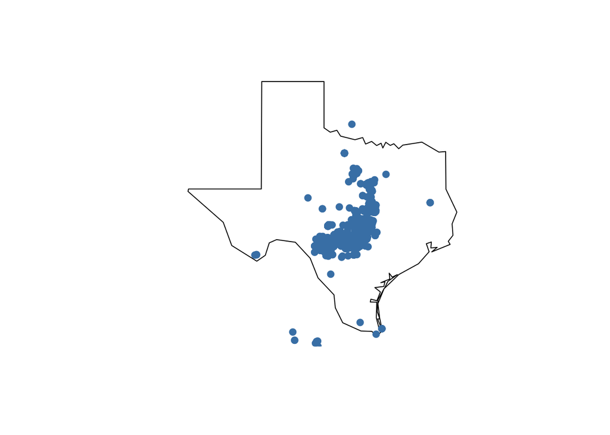

```r
# Construct the sp object
xy = cbind(gcwa$lon, gcwa$lat)
xy = xy[is.finite(xy[,1]) & is.finite(xy[, 2]), ]
gcwa.sp = SpatialPoints(xy, CRS(epsg_4326))

# Now plot
tigris::plot(texas)
points(gcwa.sp, pch = 19, col = "steelblue")
```

Let’s get rid of the points outside of Texas

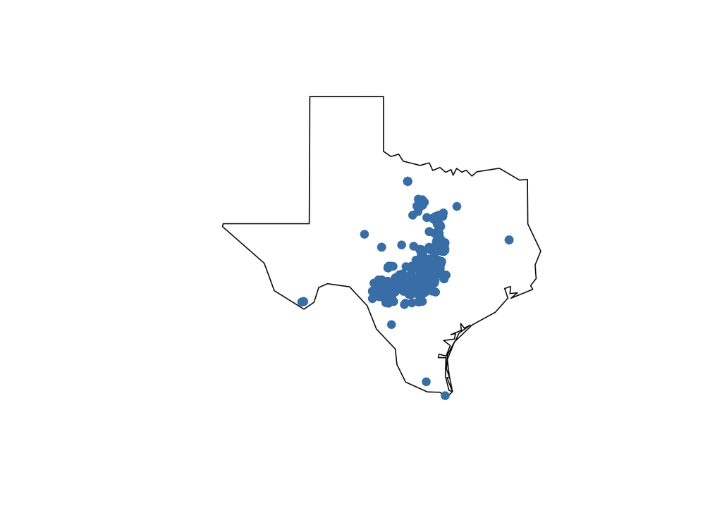

```r
pacman::p_load("rgeos")

i = gWithin(gcwa.sp, texas, byid = TRUE)  # Drop points outside
gcwa.sp = gcwa.sp[i, ]

plot(texas); points(gcwa.sp, pch = 19, col = "steelblue")
```

We can pull down [worldclim](http://www.worldclim.org/) data and use for modeling.

```r
pacman::p_load("raster")

if (!file.exists("bioclim_texas.tif")) # Just to avoid redoing this
{
  # We only want the worldclim tiles that covers texas
  wcdat1 = getData("worldclim", path = tempdir(), var = "bio", res = 0.5,
                   lon = bbox(texas)[1], lat = bbox(texas)[2])
  wcdat1 = crop(wcdat1, texas)

  # Need to get the adjacent worldclim tiles
  wcdat2 = getData("worldclim", path = tempdir(), var = "bio", res = 0.5,
                   lon = bbox(texas)[1], lat = bbox(texas)[4])
  wcdat2 = crop(wcdat2, texas)

  wcdat3 = getData("worldclim", path = tempdir(), var = "bio", res = 0.5,
                   lon = bbox(texas)[3], lat = bbox(texas)[2])
  wcdat3 = crop(wcdat3, texas)

  wcdat4 = getData("worldclim", path = tempdir(), var = "bio", res = 0.5,
                   lon = bbox(texas)[3], lat = bbox(texas)[4])
  wcdat4 = crop(wcdat4, texas)

  # Merge them together (and crop just to be sure -- not really needed)
  wcdat = crop(merge(wcdat1, wcdat2, wcdat3, wcdat4), texas)

  # Save the result
  writeRaster(wcdat, "bioclim_texas", "GTiff")
}
```

Now let’s get the data out. This is a bit slow.

```r
# Read the data from local file
# Avoids re-downloading
wcdat = brick("bioclim_texas.tif")

bioclim.df = extract(wcdat, gcwa.sp, df = TRUE)

# What we have now are the values of the raster layers at each of the observation points
head(bioclim.df)
```

```
##   ID bioclim_texas.1 bioclim_texas.2 bioclim_texas.3 bioclim_texas.4
## 1  1             193             125              37            7090
## 2  2             189             127              39            6823
## 3  3             195             122              38            6967
## 4  4             190             134              40            6932
## 5  5             190             126              39            6916
## 6  6             195             123              38            6955
##   bioclim_texas.5 bioclim_texas.6 bioclim_texas.7 bioclim_texas.8
## 1             353              24             329             232
## 2             344              22             322             226
## 3             351              30             321             233
## 4             350              18             332             229
## 5             346              23             323             228
## 6             351              30             321             234
##   bioclim_texas.9 bioclim_texas.10 bioclim_texas.11 bioclim_texas.12
```

[output cut: 20 more lines]